# Query Optimization

Author

Haylee Oyler

## Part 2

```r
library(tidyverse)
library(here)
```

```r
# Import timings data
timings <- read_csv(here("week10", "timings.csv"))
```

### Graph

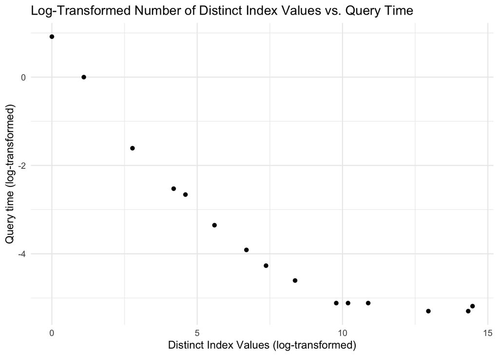

```r
# Plot log-transformed data
ggplot(timings, aes(x = log(distinct_values), y = log(time_per_rep))) +
  geom_point() +
  labs(title = "Log-Transformed Number of Distinct Index Values vs. Query Time",
       x = "Distinct Index Values (log-transformed)",
       y = "Query time (log-transformed)") +
  theme_minimal()
```

### Questions

**What relationship do you observe? Hypothesize why you see the relationship you do.**

This graph shows a strong, negative, linear relationship between distinct index values and query time, up to a certain threshold of ~ 10 (log-transformed) distinct values. This tells me that as you give an index more values to search, the query gets faster, up to a point! Eventually, you have diminishing returns where the index can get larger and larger, but the query does not get quicker. This tells me that if I were really focused on query optimization, I would always try to find that index sweet spot of maximum speed without an unnecessarily large index.

**What conclusion do you draw regarding what makes a good index?** I would conclude a good index is one that is more or less representative of whole of the table, but doesn’t need to capture everything. This let’s the database have a solid index of reference points from which to search without getting too granular. I think this value is always going to be relative to the overall size of the database. When I color by the query, I can see that the combinations of `year_observer` and `species_observer` sit right on that flattening point with approximately 20,000 distinct values. With `Bird_nests` having ~ 2 million rows, your index only needs to cover ~1% of distinct values to serve its purpose effetively.

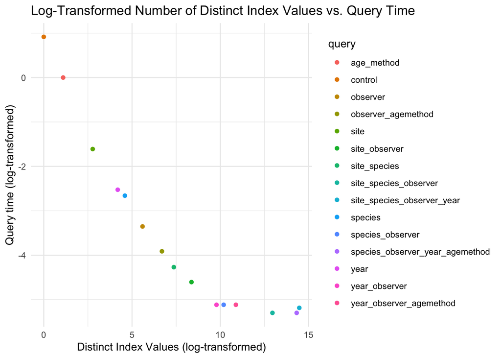

```r
# Plot log-transformed data
ggplot(timings, aes(x = log(distinct_values), y = log(time_per_rep))) +
  geom_point(aes(color = query)) +
  labs(title = "Log-Transformed Number of Distinct Index Values vs. Query Time",
       x = "Distinct Index Values (log-transformed)",
       y = "Query time (log-transformed)") +
  theme_minimal()
```